# Scrape a Website II

Grant Esparza

October, 26 2018

# Introduction

Several of our last assignments have used data from the EPA to explore the concept of webscraping. While plotting mean Air Quality Index values across counties, I noticed that Montana had especially high values in western counties during the year 2016. After learning that Montan had gone through major wildfires that year, I thought it would be useful to explore the history of the relationship between AQI and wildfires in this area. I’ll be focusing on data from the years 2005-2015.

# Preparing the data

The goal here is to aggreate information about AQI and wildfires so that I have one complete dataset I can use to do some analysis. I’ve gone through the steps of collecting each dataset individually so now I need to put it all together.

## Wildfires

For the data on wildfires, I’ll need to connect to my database and extract information about Montana:

```r
## Extract fire table from database
db <-dbConnect(SQLite(), "fire_database.sqlite")
res <- dbSendQuery(db, "SELECT * FROM Fires WHERE State == 'MT'")
fires <- dbFetch(res)
```

Next I’ll need to generate the statistics that I’m interested in. For this analysis I’ll need the total number of fires and the mean fire size. I’ll also need to make sure I group by the year and each county.

```r
## Get a tibble
montana.fires <- fires %>%
    group_by(FIRE_YEAR, FIPS_NAME) %>%
    summarise(num_fires=n(), mn_fire_size=mean(FIRE_SIZE),
              sum_fire_size=sum(FIRE_SIZE))
```

## AQI

First I need to grab the data from the EPA website. I want data from several years so I need to save these `csv` files into a folder.

```r
## Incomplete web links
get_request <- GET("https://aqs.epa.gov/aqsweb/airdata/download_files.html#AQI")
html <- content(get_request, "text")
incomplete_links <- as.data.frame(
                      str_match_all(
                        html, pattern="<a href=\"daily.*county_[0-9]{4}\\.zip\">"
                      ) ## str_match_all
                    ) ## as.data.frame

## Split
incomp_links <- as.data.frame(str_split_fixed(incomplete_links[,1],
                                              pattern="\"", 3))
colnames(incomp_links) <- c("href", "link", "end")

## Add home url
complete_links <- paste("https://aqs.epa.gov/aqsweb/airdata/",
                        incomp_links$link, sep="")

## Add data to folder
for (link in complete_links[4:14]) {
  get_request <- GET(link)
  bin_data <- content(get_request, "raw")
  writeBin(bin_data, "daily-county-aqi")
  unzip(zipfile="daily-county-aqi", exdir="aqi")
}
```

Next I need to combine these files into one dataframe. I’ll make use of the `data.table` function `fread()` to speed up the process.

```r
## Read csvs
files <- list.files(path="aqi", full.names=TRUE)

## Stack datasets
aqi.df <- rbindlist(lapply(files, fread))

## Tidy the data
colnames(aqi.df) <- c("region", "subregion", "state.code", "county.code", "date",
                      "aqi", "category", "defining.parameter", "defining.site",
                      "number.of.sites.reporting")
aqi.df$date <- year(aqi.df$date)
```

Now that I have the complete table, I’ll generate some statistics.

```r
## Get a tibble
montana.aqi <- aqi.df %>%
  filter(region == "Montana") %>%
  group_by(date, subregion) %>%
  summarise(mn_aqi=mean(aqi), md_aqi=median(aqi))
```

## Bringing it all together

Now I’ll join the datasets so I have one complete source of data. I’ll need to make sure that they have matching column names so that they join properly.

```r
## Rename columns for join
colnames(montana.fires)[colnames(montana.fires) == "FIRE_YEAR"] <- "date"
colnames(montana.fires)[colnames(montana.fires) == "FIPS_NAME"] <- "subregion"

## Join
montana.comp <- montana.aqi %>%
  inner_join(montana.fires, by=c("subregion", "date"))

montana.comp
```

```
## # A tibble: 171 x 7
## # Groups:   date [?]
##     date subregion       mn_aqi md_aqi num_fires mn_fire_size sum_fire_size
##    <int> <chr>            <dbl>  <dbl>     <int>        <dbl>         <dbl>
##  1  2005 Big Horn          28.1   23           2      421.           842.
##  2  2005 Cascade           24.2   17          13       10.3          134.
##  3  2005 Fergus            11.3    9.5         6      328.          1971.
##  4  2005 Flathead          39.3   38          88       46.6         4104.
##  5  2005 Gallatin          18.5   15          17       62.0         1054.
##  6  2005 Lake              24.0   19           9        0.238          2.14
##  7  2005 Lewis and Clark   20.9   17          30      191.          5740.
##  8  2005 Lincoln           40.3   29         132        7.14         943.
##  9  2005 Missoula          28.3   20.5       102        0.777         79.3
## 10  2005 Powell            12.6    8          24        1.26          30.2
## # ... with 161 more rows
```

# Analysis

Now that everything is in place I’d like to compare number of fires per year in each county to the mean AQI each year per county. Remember the orignal focus of this exploration was the western counties of Montana, so I’ll need to make sure my analysis considers only these counties.

## Plot the data

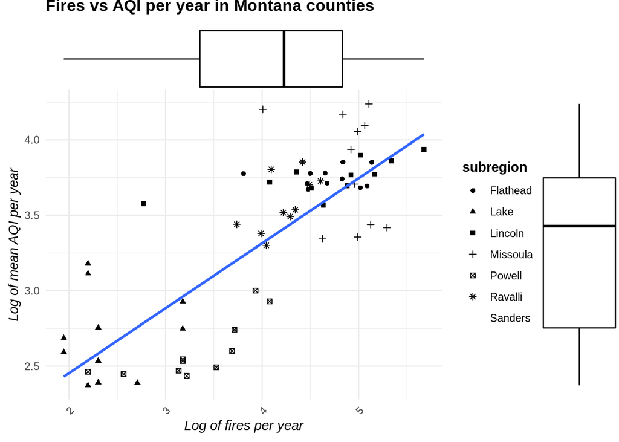

```r
## Select western counties
montana.western <- montana.comp %>%
  filter(subregion %in% c("Lincoln", "Flathead", "Sanders", "Lake", "Missoula",
                        "Ravalli", "Powell"))

## Number of fires explains mean_aqi
p <- ggplot(montana.western, aes(log(num_fires), log(mn_aqi))) +
  geom_point(aes(shape=subregion)) +
  stat_smooth(method="lm", se=FALSE) +
  ggtitle("Fires vs AQI per year in Montana counties") +
  xlab("Log of fires per year") + ylab("Log of mean AQI per year") +
  theme_minimal() +
  theme(axis.title.x = element_text(face = "italic"),
        axis.title.y = element_text(face = "italic"),
        axis.text.x = element_text(angle=45, hjust=1),
        title = element_text(face = "bold"))

## Add margin plots
ggMarginal(p, type="boxplot")
```

The plot seems to show a postive relationship between the number of fires and the mean AQI per year in each county.

## Model

Now that I have reason to believe there is a relationship, I’ll build a linear model to see how it fits.

```r
summary(lm(log(mn_aqi)~log(num_fires), data=montana.western))
```

```
##
## Call:
## lm(formula = log(mn_aqi) ~ log(num_fires), data = montana.western)
##
## Residuals:
##      Min       1Q   Median       3Q      Max
## -0.70623 -0.21941  0.02378  0.19622  0.88422
##
## Coefficients:
##                Estimate Std. Error t value Pr(>|t|)
## (Intercept)     1.59154    0.16844   9.448 2.38e-14 ***
## log(num_fires)  0.43082    0.04085  10.546  < 2e-16 ***
## ---
## Signif. codes:  0 '***' 0.001 '**' 0.01 '*' 0.05 '.' 0.1 ' ' 1
##
## Residual standard error: 0.3437 on 74 degrees of freedom
## Multiple R-squared:  0.6005, Adjusted R-squared:  0.5951
## F-statistic: 111.2 on 1 and 74 DF,  p-value: < 2.2e-16
```

The adjusted $R^{2}$ of **0.59** tells us that 59% of the variance in the log of the mean AQI per year in each county is explained by the log number of fires each year per county.

For each one percent increase in the number of fires per year in each county, there is a0.43 percent increase in the mean AQI per year in each county.

When the log number of fires per year in each county is equal to zero, the log of the mean AQI per year in each county is 1.59.

# Takeaway

This analysis supports my initial suspicion that the high AQI values in western Montana were related to large wildfires in the area. The idea that AQI is affected by wildfires is not a revolutionary concept, but it was rewarding to see my assumptions backed up by data from multiple sources.